# Geospatial Risk Modeling: Predictive Policing in Chicago

Tutut Indriaty

2024-10-18

# Introduction

**Predictive policing** is a public sector machine learning algorithm used to anticipate, prevent, and respond to future crimes more effectively by analyzing crime-related data. Predicting future crime is performed by geospatial risk model, a regression model which uses variables that can help predicting risks of crime happening in the neighborhood in the future. My outcome of interest for this modeling is predicting future assaults in the city of Chicago, especially simple assaults. **Simple assault** counts when someone knowingly causes someone else reasonably scared of being hit, such as threats or perceived threat of harm. Simple assaults may not cause physical harm directly but still have a significant impact on the sense of safety and well-being of people. Simple assault also is the most reported assault in Chicago.

However, choosing simple assaults can result in **many biases**. Starts from underreporting, when talking about simple assaults, the physical proof is none. Many people will choose not to report as they do not have “proofs” or a few of them think (which already makes this clearly biased) that it is not serious enough to be reported. After that, different backgrounds, like racial, cultural, and socio-economic can produce bias data as the wealthier and the more empowered communities report more than the marginalized ones. Lastly, **the choice of predictors**, which we will discuss further, can lead to bias if it is not apply uniformly across all areas.

# Chicago City and Simple Assaults

**a. Setup**

I start with loading all the library packages needed for this modeling process.

**b. Outcome of Interest: Simple Assaults as Dependent Variable**

The data of simple assaults of 2017 is taken from open data of the City of Chicago (data.cityofchicago.org). The results as shown in the maps display **many of reports** of the assault happening across Chicago with some concentrations in the **city center, on the west part of the city, and on the south part.**

```r
assaults <-
  read.socrata("https://data.cityofchicago.org/Public-Safety/Crimes-2017/d62x-nvdr") %>%
    filter(Primary.Type == "ASSAULT" & Description == "SIMPLE") %>%
    mutate(x = gsub("[()]", "", Location)) %>%
    separate(x,into= c("Y","X"), sep=",") %>%
    mutate(X = as.numeric(X),Y = as.numeric(Y)) %>%
    na.omit() %>%
    st_as_sf(coords = c("X", "Y"), crs = 4326, agr = "constant")%>%
    st_transform('ESRI:102271') %>%
    distinct()

chicagoBoundary <-
  st_read(file.path(root.dir,"/Chapter5/chicagoBoundary.geojson")) %>%
  st_transform('ESRI:102271')

assaults_clipped <- st_intersection(assaults, chicagoBoundary)
```

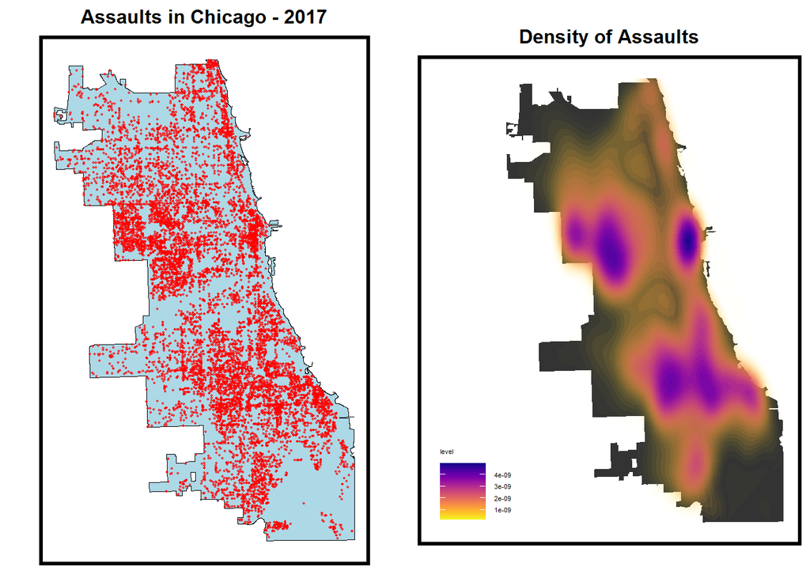

```r
grid.arrange(ncol = 2,
  ggplot() +
    geom_sf(data = chicagoBoundary, fill = "lightblue", color = "black") +
    geom_sf(data = assaults_clipped, colour = "red", size = 0.3, show.legend = "point", alpha = 0.6) +
    labs(title = "Assaults in Chicago - 2017") +
    mapTheme(title_size = 12) +
    theme(
      panel.background = element_rect(fill = "white"),
      plot.title = element_text(hjust = 0.5, face = "bold"),
      axis.text = element_blank(),
      axis.ticks = element_blank()),
  ggplot() +
    geom_sf(data = chicagoBoundary, fill = "grey20", color = "white") +
    stat_density2d(
      data = data.frame(st_coordinates(assaults)),
      aes(X, Y, fill = ..level.., alpha = ..level..),
      size = 0.2, bins = 40, geom = 'polygon') +
    scale_fill_viridis(option = "plasma", direction = -1) +
    scale_alpha(range = c(0.00, 0.5), guide = FALSE) +
    labs(title = "Density of Assaults") +
    mapTheme(title_size = 12) +
    theme(
      legend.position = c(0.15, 0.125),
      legend.title = element_text(size = 4),
      legend.text = element_text(size = 4),
      legend.key.width = unit(1, "cm"),
      legend.key.height = unit(0.25, "cm"),
      legend.background = element_rect(fill = alpha('white', 0.7), color = NA),
      panel.background = element_rect(fill = "white"),
      plot.title = element_text(hjust = 0.5, face = "bold"),
      axis.text = element_blank(),
      axis.ticks = element_blank(),
      panel.grid.major = element_line(),
      panel.grid.minor = element_blank()))
```

Using the fishnet grid, we could see the number of assaults per grid cell. The map below shows that **most assaults happen in the city center** with one grid cell of 500 m x 500 m showing assault numbers above 60 , followed by the south part with the most is in the range of 40 to 60 assaults and the west part of the city with the most is in the range of 20 to 40 assaults. From this we also recognize that the assaults are clustering.

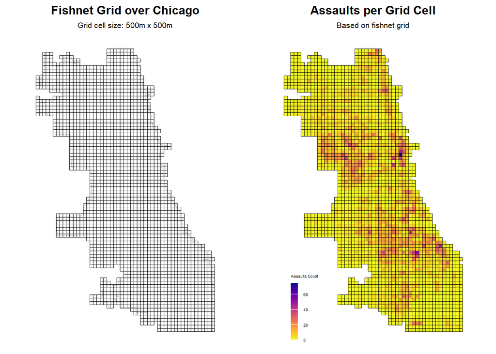

```r
fishnet <-
  st_make_grid(chicagoBoundary,
               cellsize = 500,
               square = TRUE) %>%
  .[chicagoBoundary] %>%
  st_sf() %>%
  mutate(uniqueID = 1:n())
crime_net <-
  dplyr::select(assaults_clipped) %>%
  mutate(countAssaults = 1) %>%
  aggregate(., fishnet, sum) %>%
  mutate(countAssaults = replace_na(countAssaults, 0),
         uniqueID = 1:n(),
         cvID = sample(round(nrow(fishnet) / 24),
                       size=nrow(fishnet), replace = TRUE))


grid.arrange(ncol = 2,
ggplot() +
  geom_sf(data = chicagoBoundary, fill = "white", color = "grey") +
  geom_sf(data = fishnet, color = "black", fill = NA, alpha = 0.7) +
  labs(title = "Fishnet Grid over Chicago",
       subtitle = "Grid cell size: 500m x 500m") +
  theme_minimal() +
  theme(
    plot.title = element_text(hjust = 0.5, size = 12, face = "bold"),
    plot.subtitle = element_text(hjust = 0.5, size = 8),
    axis.text = element_blank(),
    axis.ticks = element_blank(),
    panel.grid = element_blank()),
ggplot() +
  geom_sf(data = crime_net, aes(fill = countAssaults), color = NA) +
  geom_sf(data = fishnet, color = "black", fill = NA, alpha = 0.7) +
  scale_fill_viridis(option = "plasma", direction = -1, name = "Assaults Count",
                     guide = guide_colorbar(barwidth = 0.5, barheight = 4)) +
  labs(title = "Assaults per Grid Cell", subtitle = "Based on fishnet grid") +
  theme_minimal() +
  theme(
    plot.title = element_text(hjust = 0.5, size = 12, face = "bold"),
    plot.subtitle = element_text(hjust = 0.5, size = 8),
    legend.direction = "vertical",
    legend.position = c(0.15, 0.125),
    legend.title = element_text(size = 4),
    legend.text = element_text(size = 4),
    legend.key.width = unit(0.25, "cm"),
    legend.key.height = unit(2, "cm"),
    axis.text = element_blank(),
    axis.ticks = element_blank(),
    panel.grid = element_blank()))
```

# Risk Factors as Independent Variables

**a. Chosen Risk Factors**

The **risk factors** chosen for simple assaults are:

- **Metra stations** which is Chicago’s rail network as public places where legal authorities are not around every time and are mostly underground,
- **CCTV or POD (Police Observation Device) camera** as one of the supposedly proofs of what happened in the location of crime,
- **Street Lights Out** which is the complaints of people in the neighborhoods of street lights not functioned properly or broken as an opportunity of crime taking place in the dark, and
- **Liquor Retail** as places that can possibly sell liquor almost 24 hours and open in all neighborhoods not just the big ones with many people may possibly be gathering, high-stress, drunk, and half-conscious.

We clean and wrangle the data like choosing useful fields, transforming into the same projections as the dependent variable and combining the factors with the assaults data. The small multiple maps below show the two risk factors of Liquor Retails and Street Lights Out spread across Chicago city and the other two of Metro Stops and POD Cameras clustered in some areas that can lead to prediction bias.

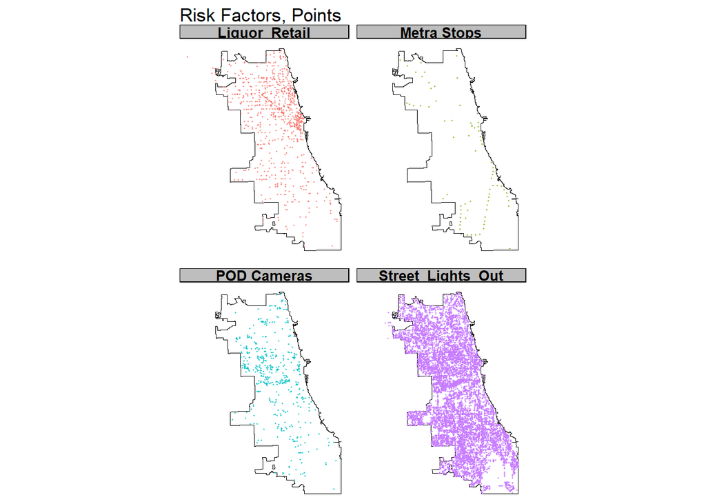

```r
metraStops <- st_read("data/MetraStations.shp") %>%
                filter(MUNICIPALI == "Chicago") %>%
                st_as_sf(coords = c("X", "Y"), crs = 4326, agr = "constant") %>%
                st_transform(st_crs(fishnet)) %>%
                dplyr::select(geometry) %>%
                mutate(Legend = "Metra Stops")
metraStops <-  st_cast(metraStops, "POINT")

cctv <- st_read("data/chicago_pod_cameras_031816.geojson") %>%
          st_as_sf(coords = c("X", "Y"), crs = 4326, agr = "constant") %>%
          st_transform(st_crs(fishnet)) %>%
          dplyr::select(geometry) %>%
          mutate(Legend = "POD Cameras")

streetLightsOut <-
  read.socrata("https://data.cityofchicago.org/Service-Requests/311-Service-Requests-Street-Lights-All-Out/zuxi-7xem") %>%
    mutate(year = substr(creation_date,1,4)) %>% filter(year == "2017") %>%
    dplyr::select(Y = latitude, X = longitude) %>%
    na.omit() %>%
    st_as_sf(coords = c("X", "Y"), crs = 4326, agr = "constant") %>%
    st_transform(st_crs(fishnet)) %>%
    mutate(Legend = "Street_Lights_Out")

liquorRetail <-
  read.socrata("https://data.cityofchicago.org/resource/nrmj-3kcf.json") %>%
    filter(business_activity == "Retail Sales of Packaged Liquor") %>%
    dplyr::select(Y = latitude, X = longitude) %>%
    na.omit() %>%
    st_as_sf(coords = c("X", "Y"), crs = 4326, agr = "constant") %>%
    st_transform(st_crs(fishnet)) %>%
    mutate(Legend = "Liquor_Retail")

neighborhoods <-
  st_read("https://raw.githubusercontent.com/blackmad/neighborhoods/master/chicago.geojson") %>%
  st_transform(st_crs(fishnet))

combined_sf <- rbind(metraStops, cctv, streetLightsOut, liquorRetail)

chicago_base_map <- ggplot() +
  geom_sf(data = chicagoBoundary, fill = "white", color = "black") +
  theme_void()

combined_map <- chicago_base_map +
  geom_sf(data = combined_sf, aes(color = Legend), size = 0.25, alpha = 0.7) +
  facet_wrap(~ Legend) +
  labs(title = "Risk Factors, Points") +
  theme(legend.position = "none",
        strip.background = element_rect(fill = "gray"),
        strip.text = element_text(size = 10, face = "bold"))

print(combined_map)
```

For these maps, the risk factors are combined with fishnet grid data therefore displaying the variables in grid cell with lighter colors as the areas with the most appeared factors. **Metra Stops map will probably show bias as the covered areas are not many** therefore can lead to a believe that the other areas without them are safer/less risk. It also applies to Liquor Retail and POD Cameras.

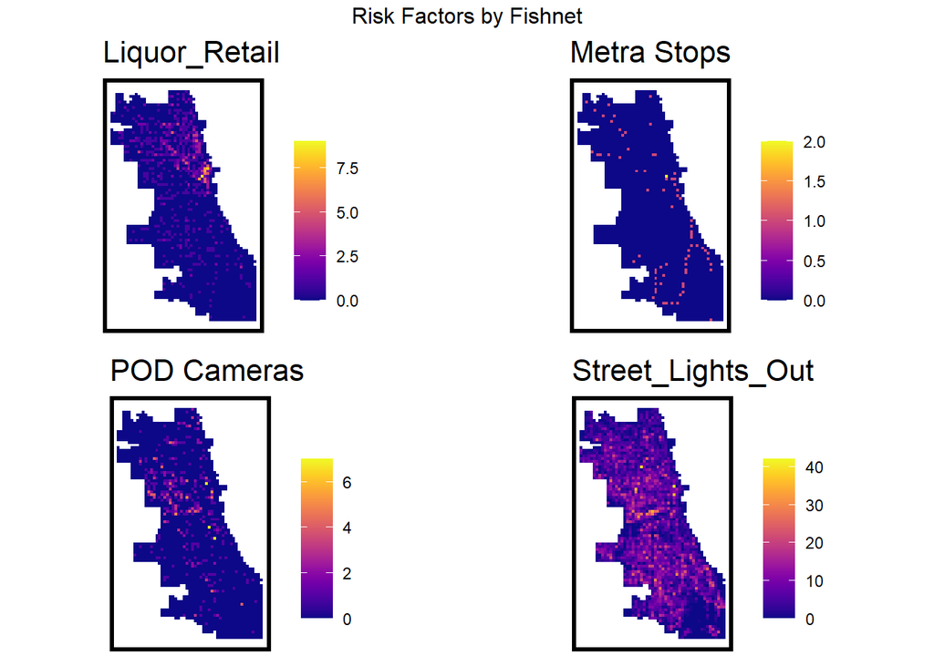

```r
vars_net <- combined_sf %>%
  st_join(fishnet, join=st_within) %>%
  st_drop_geometry() %>%
  group_by(uniqueID, Legend) %>%
  summarize(count = n()) %>%
  left_join(fishnet, ., by = "uniqueID") %>%
  spread(Legend, count, fill=0) %>%
  dplyr::select(-`<NA>`) %>%
  ungroup()

vars_net.long <-
  gather(vars_net, Variable, value, -geometry, -uniqueID)

vars <- unique(vars_net.long$Variable)
mapList <- list()

for(i in vars){
  mapList[[i]] <-
    ggplot() +
      geom_sf(data = filter(vars_net.long, Variable == i), aes(fill=value), colour=NA) +
      scale_fill_viridis(option = "plasma", name="") +
      labs(title=i) +
      mapTheme()}

do.call(grid.arrange,c(mapList, ncol=2, top="Risk Factors by Fishnet"))
```

**b. Correlative Analysis**

To know the correlation between dependent and independent variables, we use **scatterplots** to see the relation. According to the scatterplots below, all independent variables have positive relations with the dependent variable. **It is interesting especially for the risk factor of number of POD Cameras**. As the number of POD cameras increase, the number of the assault also increase. This could happen because of the areas crime history which resulted in the camera installment for the high-risk areas.

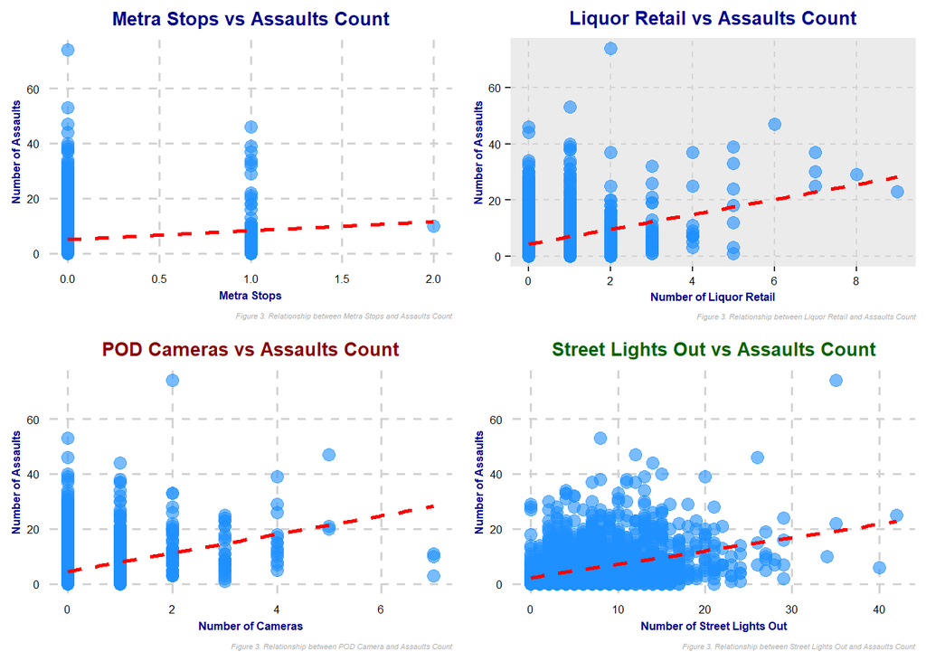

```r
combined <- cbind(crime_net, vars_net) %>%
            dplyr::select(countAssaults, uniqueID, cvID, Liquor_Retail,
                          Metra.Stops, POD.Cameras, Street_Lights_Out) %>%
            st_drop_geometry()

#MetraStops
plot1 <- ggplot(combined, aes(x = `Metra.Stops`, y = `countAssaults`)) +
  geom_point(color = "dodgerblue", alpha = 0.6, size = 3) +
  geom_smooth(method = "lm", color = "red", se = FALSE, linetype = "dashed") +
  labs(
    title = "Metra Stops vs Assaults Count",
    x = "Metra Stops",
    y = "Number of Assaults",
    caption = "Figure 3. Relationship between Metra Stops and Assaults Count"
  ) +
  scale_y_continuous() +
  theme_minimal(base_size = 12) +
  theme(
    plot.title = element_text(face = "bold", hjust = 0.5, size = 10, color = "darkblue"),
    plot.caption = element_text(hjust = 1, face = "italic", size = 4, color = "darkgray"),
    axis.title.x = element_text(face = "bold", color = "darkblue", size = 6),
    axis.title.y = element_text(face = "bold", color = "darkblue", size = 6),
    axis.text = element_text(size = 6, color = "black"),
    panel.grid.major = element_line(color = "lightgray", linetype = "dashed"),
    panel.grid.minor = element_blank(),
    plot.background = element_rect(fill = "white", color = NA)
  )

#Liquor Retail
plot2 <- ggplot(combined, aes(x = `Liquor_Retail`, y = `countAssaults`)) +
  geom_point(color = "dodgerblue", alpha = 0.6, size = 3) +
  geom_smooth(method = "lm", color = "red", se = FALSE, linetype = "dashed") +
  labs(
    title = "Liquor Retail vs Assaults Count",
    x = "Number of Liquor Retail",
    y = "Number of Assaults",
    caption = "Figure 3. Relationship between Liquor Retail and Assaults Count"
  ) +
  scale_y_continuous() +
  scale_x_continuous(breaks = scales::pretty_breaks(5)) +
  theme(
    plot.title = element_text(face = "bold", hjust = 0.5, size = 10, color = "darkblue"),
    plot.caption = element_text(hjust = 1, face = "italic", size = 4, color = "darkgray"),
    axis.title.x = element_text(face = "bold", color = "darkblue", size = 6),
    axis.title.y = element_text(face = "bold", color = "darkblue", size = 6),
    axis.text = element_text(size = 6, color = "black"),
    panel.grid.major = element_line(color = "lightgray", linetype = "dashed"),
    panel.grid.minor = element_blank(),
    plot.background = element_rect(fill = "white", color = NA)
  )

#POD Cameras
plot3 <-ggplot(combined, aes(x = `POD.Cameras`, y = `countAssaults`)) +
  geom_point(color = "dodgerblue", alpha = 0.6, size = 3) +
  geom_smooth(method = "lm", color = "red", se = FALSE, linetype = "dashed") +
  labs(
    title = "POD Cameras vs Assaults Count",
    x = "Number of Cameras",
    y = "Number of Assaults",
    caption = "Figure 3. Relationship between POD Camera and Assaults Count"
  ) +
  scale_y_continuous() +
  scale_x_continuous() +
  theme_minimal(base_size = 12) +
  theme(
    plot.title = element_text(face = "bold", hjust = 0.5, size = 10, color = "darkred"),
    plot.caption = element_text(hjust = 1, face = "italic", size = 4, color = "darkgray"),
    axis.title.x = element_text(face = "bold", color = "darkblue", size = 6),
    axis.title.y = element_text(face = "bold", color = "darkblue", size = 6),
    axis.text = element_text(size = 6, color = "black"),
    panel.grid.major = element_line(color = "lightgray", linetype = "dashed"),
    panel.grid.minor = element_blank(),
    plot.background = element_rect(fill = "white", color = NA)
  )

#Street Lights Out
plot4 <- ggplot(combined, aes(x = `Street_Lights_Out`, y = `countAssaults`)) +
  geom_point(color = "dodgerblue", alpha = 0.6, size = 3) +
  geom_smooth(method = "lm", color = "red", se = FALSE, linetype = "dashed") +
  labs(
    title = "Street Lights Out vs Assaults Count",
    x = "Number of Street Lights Out",
    y = "Number of Assaults",
    caption = "Figure 3. Relationship between Street Lights Out and Assaults Count"
  ) +
  scale_y_continuous() +
  scale_x_continuous() +
  theme_minimal(base_size = 12) +
  theme(
    plot.title = element_text(face = "bold", hjust = 0.5, size = 10, color = "darkgreen"),
    plot.caption = element_text(hjust = 1, face = "italic", size = 4, color = "darkgray"),
    axis.title.x = element_text(face = "bold", color = "darkblue", size = 6),
    axis.title.y = element_text(face = "bold", color = "darkblue", size = 6),
    axis.text = element_text(size = 6, color = "black"),
    panel.grid.major = element_line(color = "lightgray", linetype = "dashed"),
    panel.grid.minor = element_blank(),
    plot.background = element_rect(fill = "white", color = NA)
  )

grid.arrange(plot1, plot2, plot3, plot4, ncol = 2)
```

**c. Feature Engineering**

First, we use nearest neighbor feature to check exposures by distance. By choosing k=3, the maps will show the **3 nearest neighboring points** and use those to calculate the proximity to certain risk factors.The maps below show four independent variables and the distance from each grid cell to its nearest variables each. We can see **most of the areas for all variables are in the lowest range of average distance**. For POD Cameras, it shows the least exposures are only on the most northern and southern part of Chicago. For Liquor retail and street lights out, the least exposure is in the most southern part of Chicago. For Metra Stops, the least exposure is when it is far from metra stops.

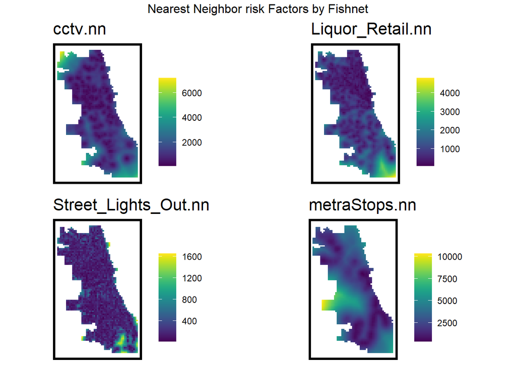

```r
st_c <- st_coordinates
st_coid <- st_centroid

vars_net <-
  vars_net %>%
    mutate(
      cctv.nn =
        nn_function(st_c(st_coid(vars_net)), st_c(cctv),3),
      Liquor_Retail.nn =
        nn_function(st_c(st_coid(vars_net)), st_c(liquorRetail),3),
      Street_Lights_Out.nn =
        nn_function(st_c(st_coid(vars_net)), st_c(streetLightsOut),3),
      metraStops.nn =
        nn_function(st_c(st_coid(vars_net)), st_c(metraStops),3))

vars_net.long.nn <-
  dplyr::select(vars_net, ends_with(".nn")) %>%
    gather(Variable, value, -geometry)

vars <- unique(vars_net.long.nn$Variable)
mapList <- list()

for(i in vars){
  mapList[[i]] <-
    ggplot() +
      geom_sf(data = filter(vars_net.long.nn, Variable == i), aes(fill=value), colour=NA) +
      scale_fill_viridis(name="") +
      labs(title=i) +
      mapTheme()}

do.call(grid.arrange,c(mapList, ncol = 2, top = "Nearest Neighbor risk Factors by Fishnet"))
```

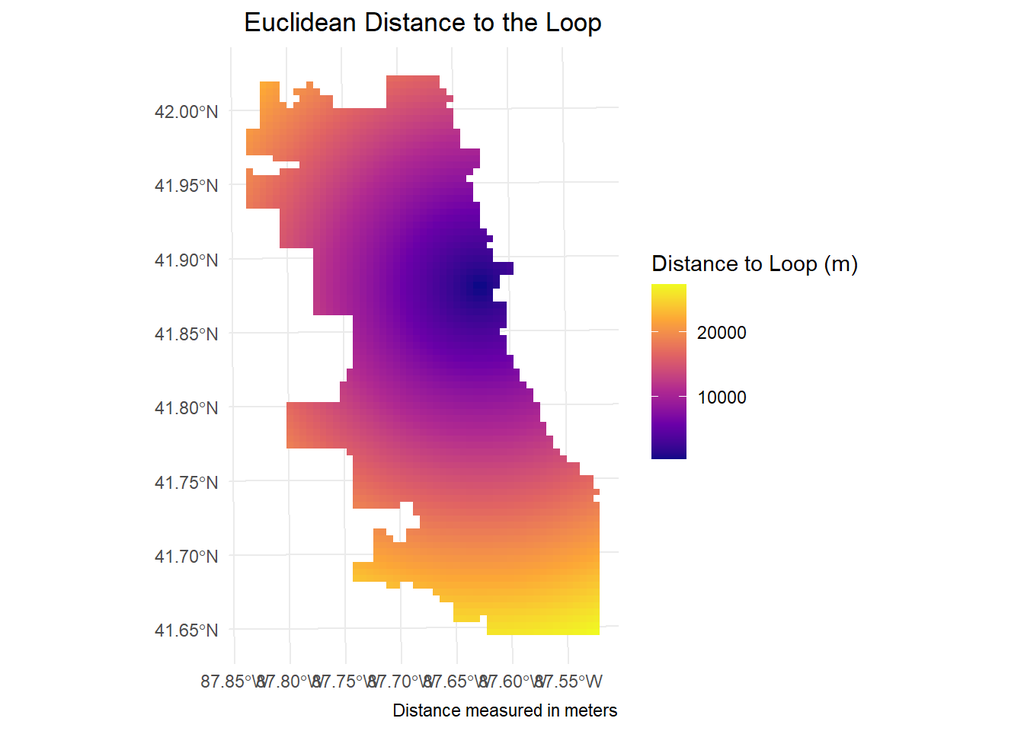

```r
loopPoint <-
  filter(neighborhoods, name == "Loop") %>%
  st_centroid()

vars_net$loopDistance =
  st_distance(st_centroid(vars_net),loopPoint) %>%
  as.numeric()

ggplot() +
  geom_sf(data = vars_net, aes(fill = loopDistance), color = NA) +
  scale_fill_viridis_c(option = "plasma", name = "Distance to Loop (m)") +
  labs(title = "Euclidean Distance to the Loop",
       caption = "Distance measured in meters") +
  theme_minimal() +
  theme(legend.position = "right",
        plot.title = element_text(hjust = 0.5))
```

Lastly, we use Police District and Neighborhoods data to be joined with the dependent and independent variables for regression model.

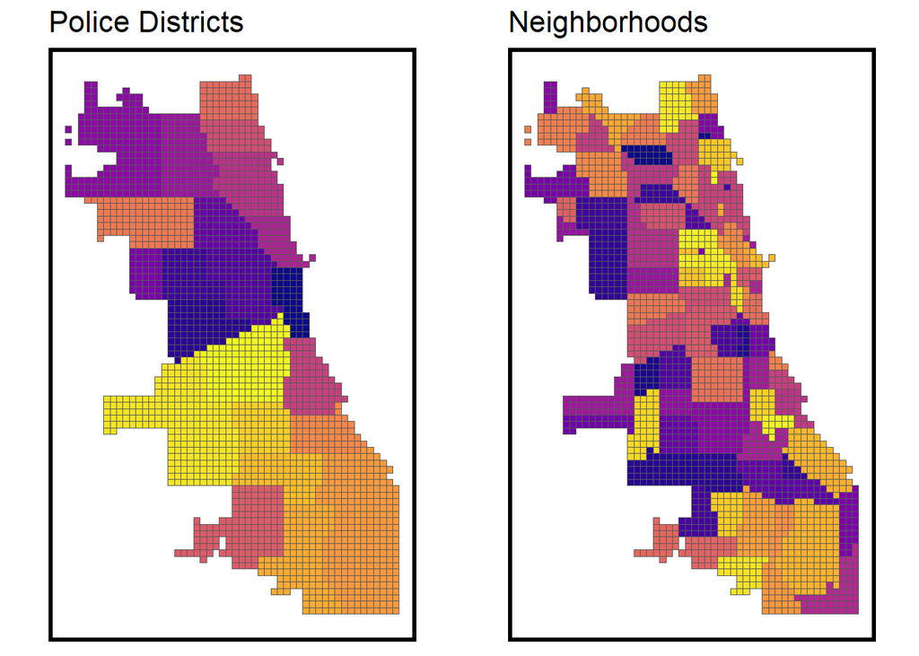

```r
final_net <-
  left_join(crime_net, st_drop_geometry(vars_net), by="uniqueID")

policeDistricts <-
  st_read("https://data.cityofchicago.org/api/geospatial/fthy-xz3r?method=export&format=GeoJSON") %>%
  st_transform('ESRI:102271') %>%
  dplyr::select(District = dist_num)

final_net <-
  st_centroid(final_net) %>%
    st_join(dplyr::select(neighborhoods, name)) %>%
    st_join(dplyr::select(policeDistricts, District)) %>%
      st_drop_geometry() %>%
      left_join(dplyr::select(final_net, geometry, uniqueID)) %>%
      st_sf() %>%
  na.omit()

grid.arrange(ncol=2,
ggplot() +
      geom_sf(data = final_net, aes(fill=District)) +
       scale_fill_viridis_d(option = "plasma") +
      labs(title="Police Districts") +
      mapTheme()+
      theme(legend.position = "none"),

ggplot() +
      geom_sf(data = final_net, aes(fill=name)) +
       scale_fill_viridis_d(option = "plasma") +
      labs(title="Neighborhoods") +
      mapTheme()+
      theme(legend.position = "none"))
```

# Local Moran’s I

We use local moran’s I to assess spatial autocorrelation at a local level and identify clusters or outliers in the spatial distribution of variables. This detects hotspots (clusters of high values), coldspots (clusters of low values), and spatial outliers (areas where a location has a value that is significantly different from its neighbors).

The result for Local Moran’s I map above display **hotspots (brighter color) meaning high crime rate surrounded by other high-crime areas, which is in the city center.** For P-Value map and significant hotspots, we will talk about that further.

This information is useful to realize that a model needs to be generalizable therefore it can predict equally well in the hotspots and in the coldspots. We can see from **assaults count map and significant hotspots that they align which means a possible good generalization**.

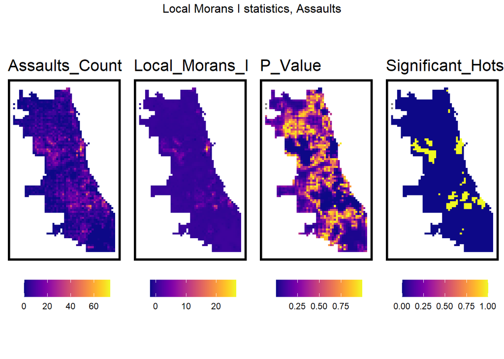

```r
final_net.nb <- poly2nb(as_Spatial(final_net), queen=TRUE)
final_net.weights <- nb2listw(final_net.nb, style="W", zero.policy=TRUE)

print(final_net.weights, zero.policy=TRUE)

local_morans <- localmoran(final_net$countAssaults, final_net.weights, zero.policy=TRUE) %>%                 as.data.frame()

# join local Moran's I results to fishnet
final_net.localMorans <-
  cbind(local_morans, as.data.frame(final_net)) %>%
  st_sf() %>%
  dplyr::select(Assaults_Count = countAssaults,
                Local_Morans_I = Ii,
                P_Value = `Pr(z != E(Ii))`) %>%
  mutate(Significant_Hotspots = ifelse(P_Value <= 0.001, 1, 0)) %>%
  gather(Variable, Value, -geometry)

vars <- unique(final_net.localMorans$Variable)
varList <- list()

for(i in vars){
  varList[[i]] <-
    ggplot() +
      geom_sf(data = filter(final_net.localMorans, Variable == i),
              aes(fill = Value), colour=NA) +
      scale_fill_viridis(option = "plasma", name="") +
      labs(title=i) +
      mapTheme() + theme(legend.position="bottom")}

do.call(grid.arrange,c(varList, ncol = 4, top = "Local Morans I statistics, Assaults"))
```

We distribute the significance which is shown by the p-value to 4 different categories. For the p-value nearing 0.1, the significant hotspots increase. This means that **more hotspots are insignificant with the clusters and the observed local Moran’s I statistic is likely due to random chance**.

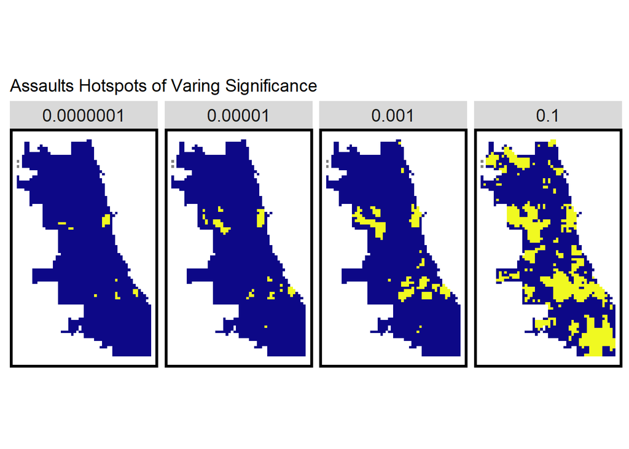

```r
final_net.localMoransbypval <-
  cbind(local_morans, as.data.frame(final_net)) %>%
  st_sf() %>%
  dplyr::select(Assaults_Count = countAssaults,
                Local_Morans_I = Ii,
                P_Value = `Pr(z != E(Ii))`) %>%
  mutate(Significant_Hotspots0.1 = ifelse(P_Value <= 0.1 , 1, 0)) %>%
  mutate(Significant_Hotspots0.001 = ifelse(P_Value <= 0.001 , 1, 0)) %>%
  mutate(Significant_Hotspots0.00001 = ifelse(P_Value <= 0.00001 , 1, 0)) %>%
  mutate(Significant_Hotspots0.0000001 = ifelse(P_Value <= 0.0000001, 1, 0)) %>%
  gather(Variable, Value, -geometry)

final_net.localMoransbypval <- subset(final_net.localMoransbypval, grepl("Significant_Hotspots", Variable))

custom_labels <- c("Significant_Hotspots0.1" = "0.1",
                   "Significant_Hotspots0.001" = "0.001",
                   "Significant_Hotspots0.00001" = "0.00001",
                   "Significant_Hotspots0.0000001" = "0.0000001")

ggplot() +
      geom_sf(data = final_net.localMoransbypval,
              aes(fill = Value), colour=NA) +
      scale_fill_viridis(option = "plasma", name="") +
      labs(title="Assaults Hotspots of Varing Significance") +
      facet_wrap(~Variable, ncol=4, labeller = labeller(Variable = custom_labels))+
      mapTheme(title_size = 14) + theme(legend.position="none")
```

The map below shows average nearest neighbor distance from each cell centroid to its nearest significant cluster. We use only the significant hotspots with p-value less than 0.001. **The highest average distance** is only **in the most southern and northern part of the city** which **aligns** with ithaving **the least exposure of crime from nearest neighbor feature**.

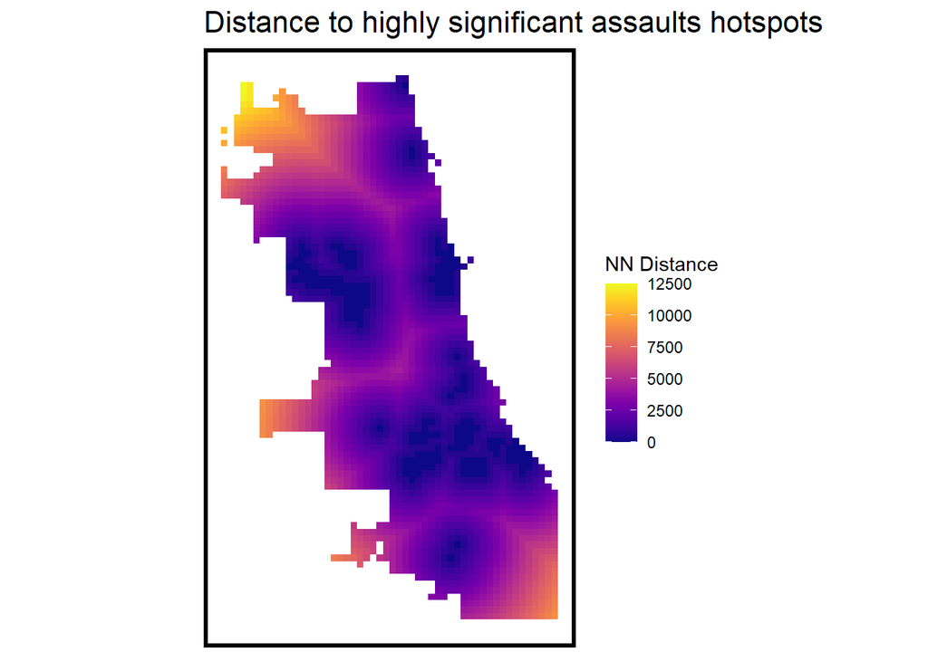

```r
final_net <- final_net %>%
  mutate(assaultscount.isSig =
           ifelse(local_morans[,5] <= 0.001, 1, 0)) %>%
  mutate(assaultscount.isSig.dist =
           nn_function(st_coordinates(st_centroid(final_net)),
                       st_coordinates(st_centroid(filter(final_net,
                                           assaultscount.isSig == 1))),
                       k = 1))

ggplot() +
      geom_sf(data = final_net, aes(fill=assaultscount.isSig.dist), colour=NA) +
      scale_fill_viridis(option = "plasma", name="NN Distance") +
      labs(title="Distance to highly significant assaults hotspots") +
      mapTheme()
```

# Modeling and Cross-Validation

We use geospatial risk modeling to predict future possible crime and cross-validation to get the most accurate model.

**a. Choosing Models**

I choose the model with removing one of the independent variables one by one and use cross-validation to count Mean Absolute Error (MAE). **The lowest the MAE, the better the model**.

```r
reg.vars.full <- c("cctv.nn", "Street_Lights_Out.nn", "Liquor_Retail.nn", "metraStops.nn", "loopDistance")

reg.vars.no_cctv <- setdiff(reg.vars.full, "cctv.nn")
reg.vars.no_street_lights <- setdiff(reg.vars.full, "Street_Lights_Out.nn")
reg.vars.no_liquor <- setdiff(reg.vars.full, "Liquor_Retail.nn")
reg.vars.no_metra <- setdiff(reg.vars.full, "metraStops.nn")

models <- list(
  "Full Model" = reg.vars.full,
  "No CCTV" = reg.vars.no_cctv,
  "No Street Lights" = reg.vars.no_street_lights,
  "No Liquor Retail" = reg.vars.no_liquor,
  "No Metra Stops" = reg.vars.no_metra
)

model_results <- lapply(names(models), function(model_name) {
  vars <- models[[model_name]]
  model_cv <- crossValidate(
    dataset = final_net,
    id = "name",
    dependentVariable = "countAssaults",
    indVariables = vars
  ) %>%
    dplyr::select(cvID = name, countAssaults, Prediction, geometry)
  model_summary <- model_cv %>%
    mutate(Error = Prediction - countAssaults) %>%
    summarize(
      MAE = mean(abs(Error), na.rm = TRUE)
    )
  return(data.frame(Model = model_name, MAE = model_summary$MAE))
})

model_results_df <- do.call(rbind, model_results)

model_results_df %>%
  kable(caption = "Comparison of MAE for Different Models") %>%
  kable_styling("striped", full_width = F)
```

[output not shown]

**b. Final Model and Accuracy**

Using the final model with four independent variables, loop distance, and the average distance of significant hotspots, we cross-validate the model to see the accuracy of the model.

```r
reg.vars <- c("cctv.nn", "Street_Lights_Out.nn", "Liquor_Retail.nn",
              "metraStops.nn", "loopDistance")

reg.ss.vars <- c("cctv.nn", "Street_Lights_Out.nn", "Liquor_Retail.nn",
                 "metraStops.nn", "loopDistance", "assaultscount.isSig",
                 "assaultscount.isSig.dist")

reg.spatialCV <- crossValidate(
  dataset = final_net,
  id = "name",
  dependentVariable = "countAssaults",
  indVariables = reg.vars) %>%
    dplyr::select(cvID = name, countAssaults, Prediction, geometry)

reg.ss.spatialCV <- crossValidate(
  dataset = final_net,
  id = "name",
  dependentVariable = "countAssaults",
  indVariables = reg.ss.vars) %>%
    dplyr::select(cvID = name, countAssaults, Prediction, geometry)


reg.summary <-
  rbind(
    mutate(reg.spatialCV,    Error = Prediction - countAssaults,
                             Regression = "Spatial LOGO-CV: Just Risk Factors"),

    mutate(reg.ss.spatialCV, Error = Prediction - countAssaults,
                             Regression = "Spatial LOGO-CV: Spatial Process")) %>%
    st_sf()
```

The errors are shown by Mean Error, Mean Absolute Error, and Standard Deviation of Mean Absolute Error. The histogram below shows the distribution of MAE for the cross-validation of just risk factors and the one with the spatial process. There is a difference between the two histogram that will show the importance of spatial process in this model. I will write further by the map and table.

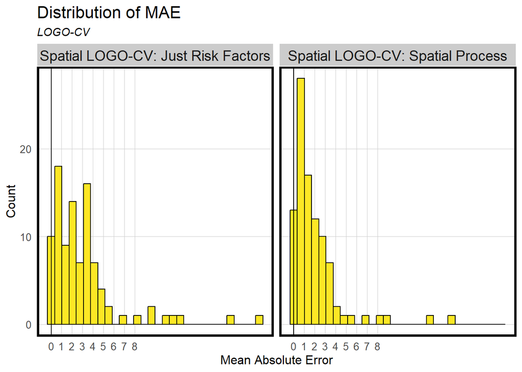

```r
error_by_reg_and_fold <-
  reg.summary %>%
    group_by(Regression, cvID) %>%
    summarize(Mean_Error = mean(Prediction - countAssaults, na.rm = T),
              MAE = mean(abs(Mean_Error), na.rm = T),
              SD_MAE = mean(abs(Mean_Error), na.rm = T)) %>%
  ungroup()

error_by_reg_and_fold %>%
  ggplot(aes(MAE)) +
    geom_histogram(bins = 30, colour="black", fill = "#FDE725FF") +
    facet_wrap(~Regression) +
    geom_vline(xintercept = 0) + scale_x_continuous(breaks = seq(0, 8, by = 1)) +
    labs(title="Distribution of MAE", subtitle = "LOGO-CV",
         x="Mean Absolute Error", y="Count") +
    plotTheme()
```

The maps below show l**ower MAE for the model with spatial process which means better model** and the spatial feature plays an **important role** in the prediction.

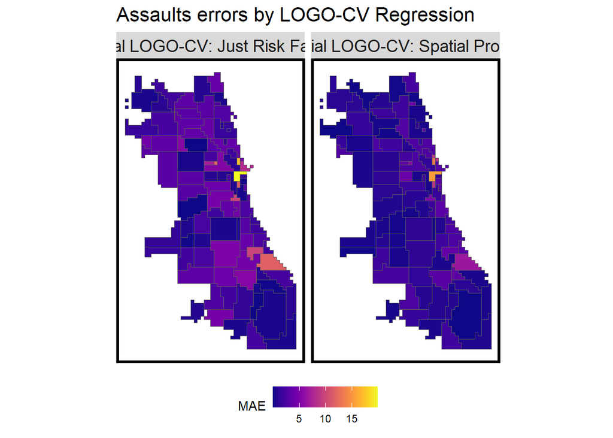

```r
error_by_reg_and_fold %>%
  filter(str_detect(Regression, "LOGO")) %>%
  ggplot() +
    geom_sf(aes(fill = MAE)) +
    facet_wrap(~Regression) +
    scale_fill_viridis(option = "plasma") +
    labs(title = "Assaults errors by LOGO-CV Regression") +
    mapTheme() + theme(legend.position="bottom")
```

```r
st_drop_geometry(error_by_reg_and_fold) %>%
  group_by(Regression) %>%
    summarize(Mean_MAE = round(mean(MAE), 2),
              SD_MAE = round(sd(MAE), 2)) %>%
  kable() %>%
    kable_styling("striped", full_width = F)
```

[output not shown]

**c. Neighborhood Racial Context**

```r
tracts18 <-
  get_acs(geography = "tract", variables = c("B01001_001E","B01001A_001E"),
          year = 2018, state=17, county=031, geometry=T) %>%
  st_transform('ESRI:102271')  %>%
  dplyr::select(variable, estimate, GEOID) %>%
  spread(variable, estimate) %>%
  rename(TotalPop = B01001_001,
         NumberWhites = B01001A_001) %>%
  mutate(percentWhite = NumberWhites / TotalPop,
         raceContext = ifelse(percentWhite > .5, "Majority_White", "Majority_Non_White")) %>%
  .[neighborhoods,]

reg.summary %>%
  filter(str_detect(Regression, "LOGO")) %>%
    st_centroid() %>%
    st_join(tracts18) %>%
    na.omit() %>%
      st_drop_geometry() %>%
      group_by(Regression, raceContext) %>%
      summarize(mean.Error = mean(Error, na.rm = T)) %>%
      spread(raceContext, mean.Error) %>%
      kable(caption = "Mean Error by neighborhood racial context") %>%
        kable_styling("striped", full_width = F)
```

[output not shown]

# Kernel’s Density and Model Prediction

**a. Kernel’s Density**

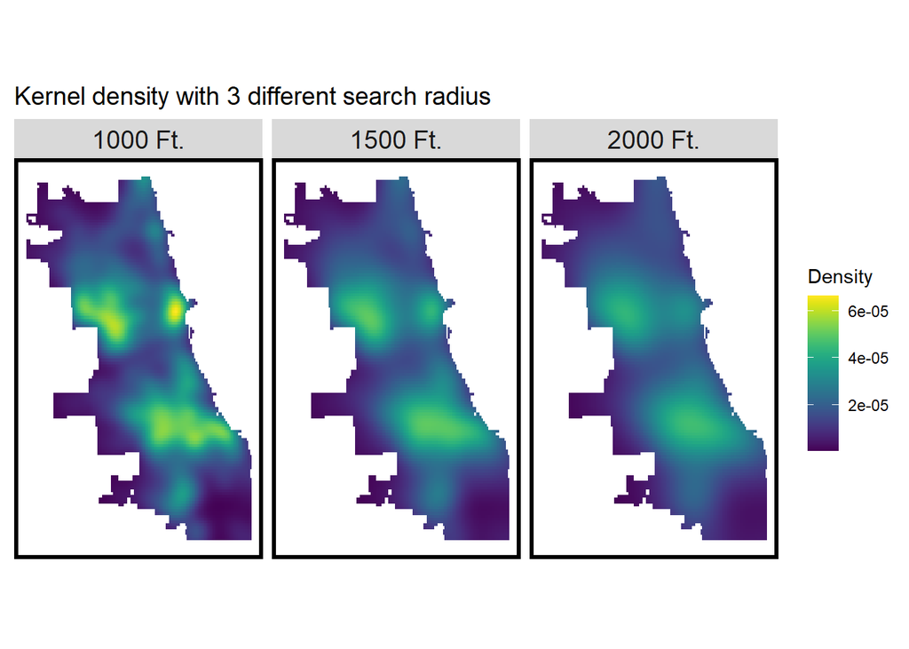

```r
assa_ppp <- as.ppp(st_coordinates(assaults_clipped), W = st_bbox(final_net))
assa_KD.1000 <- spatstat.explore::density.ppp(assa_ppp, 1000)
assa_KD.1500 <- spatstat.explore::density.ppp(assa_ppp, 1500)
assa_KD.2000 <- spatstat.explore::density.ppp(assa_ppp, 2000)
assa_KD.df <- rbind(
  mutate(data.frame(rasterToPoints(mask(raster(assa_KD.1000), as(neighborhoods, 'Spatial')))), Legend = "1000 Ft."),
  mutate(data.frame(rasterToPoints(mask(raster(assa_KD.1500), as(neighborhoods, 'Spatial')))), Legend = "1500 Ft."),
  mutate(data.frame(rasterToPoints(mask(raster(assa_KD.2000), as(neighborhoods, 'Spatial')))), Legend = "2000 Ft."))

assa_KD.df$Legend <- factor(assa_KD.df$Legend, levels = c("1000 Ft.", "1500 Ft.", "2000 Ft."))

ggplot(data=assa_KD.df, aes(x=x, y=y)) +
  geom_raster(aes(fill=layer)) +
  facet_wrap(~Legend) +
  coord_sf(crs=st_crs(final_net)) +
  scale_fill_viridis(name="Density") +
  labs(title = "Kernel density with 3 different search radius") +
  mapTheme(title_size = 14)
```

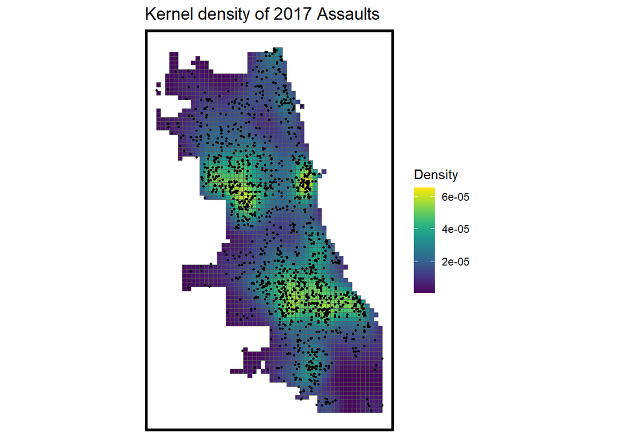

```r
as.data.frame(assa_KD.1000) %>%
  st_as_sf(coords = c("x", "y"), crs = st_crs(final_net)) %>%
  aggregate(., final_net, mean) %>%
   ggplot() +
     geom_sf(aes(fill=value)) +
     geom_sf(data = sample_n(assaults_clipped, 1500), size = .5) +
     scale_fill_viridis(name = "Density") +
     labs(title = "Kernel density of 2017 Assaults") +
     mapTheme(title_size = 14)
```

**b. Comparison with Model Prediction**

Now, we compare the 2018 assaults data with the Model Prediction using 2017 assaults data. Overall, **the highest risks (5th category)** are still in the three areas mentioned before: **the city center, west Chicago, and south Chicago**. The maps below show while there are similarities in a few areas, there are differences in many more areas.

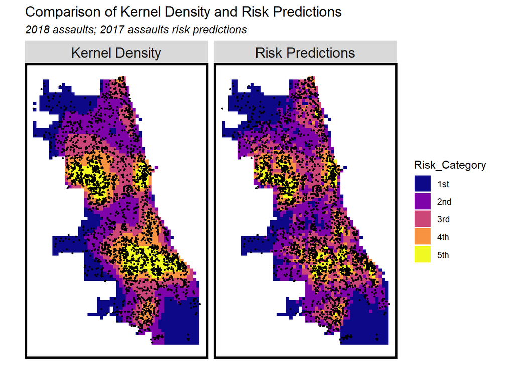

```r
assaults18 <-
  read.socrata("https://data.cityofchicago.org/Public-Safety/Crimes-2018/3i3m-jwuy") %>%
  filter(Primary.Type == "ASSAULT" &
         Description == "SIMPLE") %>%
  mutate(x = gsub("[()]", "", Location)) %>%
  separate(x,into= c("Y","X"), sep=",") %>%
  mutate(X = as.numeric(X),
         Y = as.numeric(Y)) %>%
  na.omit %>%
  st_as_sf(coords = c("X", "Y"), crs = 4326, agr = "constant") %>%
  st_transform('ESRI:102271') %>%
  distinct() %>%
  .[fishnet,]

assa_KDE_sum <- as.data.frame(assa_KD.1000) %>%
  st_as_sf(coords = c("x", "y"), crs = st_crs(final_net)) %>%
  aggregate(., final_net, mean)


kde_breaks <- classIntervals(assa_KDE_sum$value,
                             n = 5, "fisher")


assa_KDE_sf <- assa_KDE_sum %>%
  mutate(label = "Kernel Density",
         Risk_Category = classInt::findCols(kde_breaks),
         Risk_Category = case_when(
           Risk_Category == 5 ~ "5th",
           Risk_Category == 4 ~ "4th",
           Risk_Category == 3 ~ "3rd",
           Risk_Category == 2 ~ "2nd",
           Risk_Category == 1 ~ "1st")) %>%
  cbind(
    aggregate(
      dplyr::select(assaults18) %>% mutate(assaCount = 1), ., sum) %>%
    mutate(assaCount = replace_na(assaCount, 0))) %>%
  dplyr::select(label, Risk_Category, assaCount)

ml_breaks <- classIntervals(reg.ss.spatialCV$Prediction,
                             n = 5, "fisher")
assa_risk_sf <-
  reg.ss.spatialCV %>%
  mutate(label = "Risk Predictions",
         Risk_Category =classInt::findCols(ml_breaks),
         Risk_Category = case_when(
           Risk_Category == 5 ~ "5th",
           Risk_Category == 4 ~ "4th",
           Risk_Category == 3 ~ "3rd",
           Risk_Category == 2 ~ "2nd",
           Risk_Category == 1 ~ "1st")) %>%
  cbind(
    aggregate(
      dplyr::select(assaults18) %>% mutate(assaCount = 1), ., sum) %>%
      mutate(assaCount = replace_na(assaCount, 0))) %>%
  dplyr::select(label,Risk_Category, assaCount)

rbind(assa_KDE_sf, assa_risk_sf) %>%
  na.omit() %>%
  gather(Variable, Value, -label, -Risk_Category, -geometry) %>%
  ggplot() +
    geom_sf(aes(fill = Risk_Category), colour = NA) +
    geom_sf(data = sample_n(assaults18, 3000), size = .5, colour = "black") +
    facet_wrap(~label, ) +
    scale_fill_viridis(option = "plasma", discrete = TRUE) +
    labs(title="Comparison of Kernel Density and Risk Predictions",
         subtitle="2018 assaults; 2017 assaults risk predictions") +
    mapTheme(title_size = 14)
```

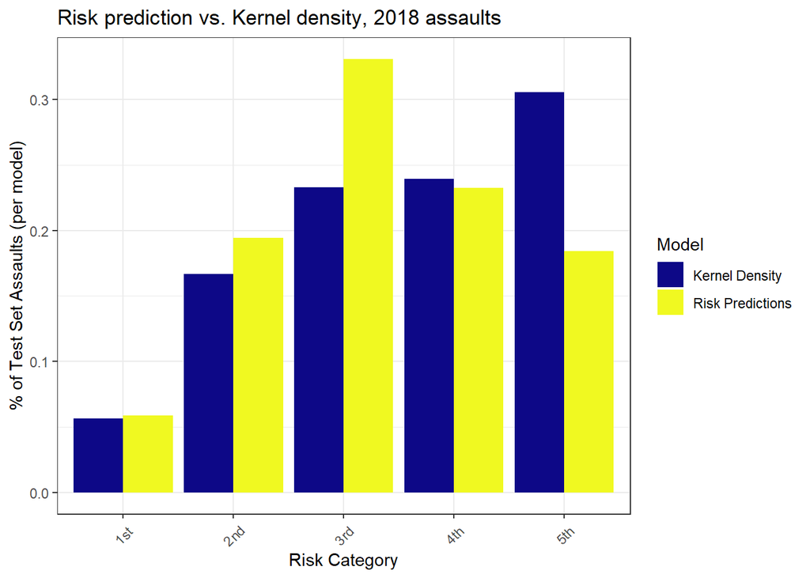

```r
rbind(assa_KDE_sf, assa_risk_sf) %>%
  st_drop_geometry() %>%
  na.omit() %>%
  gather(Variable, Value, -label, -Risk_Category) %>%
  group_by(label, Risk_Category) %>%
  summarize(countAssaults = sum(Value)) %>%
  ungroup() %>%
  group_by(label) %>%
  mutate(Pcnt_of_test_set_crimes = countAssaults / sum(countAssaults)) %>%
    ggplot(aes(Risk_Category,Pcnt_of_test_set_crimes)) +
      geom_bar(aes(fill=label), position="dodge", stat="identity") +
      scale_fill_viridis(option = "plasma", discrete = TRUE, name = "Model") +
      labs(title = "Risk prediction vs. Kernel density, 2018 assaults",
           y = "% of Test Set Assaults (per model)",
           x = "Risk Category") +
  theme_bw() +
      theme(axis.text.x = element_text(angle = 45, vjust = 0.5))
```

# Conclusion

**Simple Assaults** as the chosen outcomes also is not an easy category of crimes to predict because of the **quite high level of bias in data**. But this still is important because this assault type is the **highest crime reports** in Chicago. **Better and stronger variables** need to be included in the modeling to create reliable prediction. Some variable ideas to add to probably improve the modeling in the future are religious locations, recreational places, education level, and income level.